# MUSA 508, Lab 5 - Spatial Machine Learning Pt. 2

Harris, Fichman and Steif - 2023

2023-09-26

## Learning objectives

- Build a training and testing environment to validate a regression model
- Examine Errors to understand if they are non-random, in order to diagnose model quality
- Create and examine validation metrics including MAE and MAPE
- Use Moran’s I to see if errors are spatially non-random
- Examine generalizability across geographic contexts

## Data Loading

Bring in a wrangled data set - it has some new variables already created.

```r
#https://github.com/urbanSpatial/Public-Policy-Analytics-Landing/tree/master/DATA/Chapter3_4


boston.sf <- st_read(file.path(root.dir,"/Chapter3_4/boston_sf_Ch1_wrangled.geojson")) %>%
  st_set_crs('ESRI:102286')
nhoods <-
  st_read("https://raw.githubusercontent.com/mafichman/musa_5080_2023/main/Week_4/neighborhoods/bost_nhoods.geojson") %>%
  st_transform('ESRI:102286')
```

## Split Data into Train/Test Set

- What is the size of the split in the data partition?
- What do the errors messages mean? If there is a single record in a category - it gets sorted into the training set. Why??
- Can you figure out what’s going on when we create our error metrics?

```r
inTrain <- createDataPartition(
              y = paste(boston.sf$Name, boston.sf$NUM_FLOORS.cat,
                        boston.sf$Style, boston.sf$R_AC),
              p = .60, list = FALSE)
```

[output not shown]

```r
boston.training <- boston.sf[inTrain,]
boston.test <- boston.sf[-inTrain,]

reg.training <-
  lm(SalePrice ~ ., data = as.data.frame(boston.training) %>%
                             dplyr::select(SalePrice, LivingArea, Style,
                                           GROSS_AREA, NUM_FLOORS.cat,
                                           R_BDRMS, R_FULL_BTH, R_HALF_BTH,
                                           R_KITCH, R_AC, R_FPLACE, crimes.Buffer))

boston.test <-
  boston.test %>%
  mutate(Regression = "Baseline Regression",
         SalePrice.Predict = predict(reg.training, boston.test),
         SalePrice.Error = SalePrice.Predict - SalePrice,
         SalePrice.AbsError = abs(SalePrice.Predict - SalePrice),
         SalePrice.APE = (abs(SalePrice.Predict - SalePrice)) / SalePrice.Predict)%>%
  filter(SalePrice < 5000000)
```

## Spatial Lags

What is the relationship between errors? Are they clustered? Is the error of a single observation correlated with the error of nearby observations?

We create a list of “neigbhors” using a “spatial weights matrix”.

```r
coords <- st_coordinates(boston.sf)

neighborList <- knn2nb(knearneigh(coords, 5))

spatialWeights <- nb2listw(neighborList, style="W")

boston.sf$lagPrice <- lag.listw(spatialWeights, boston.sf$SalePrice)
```

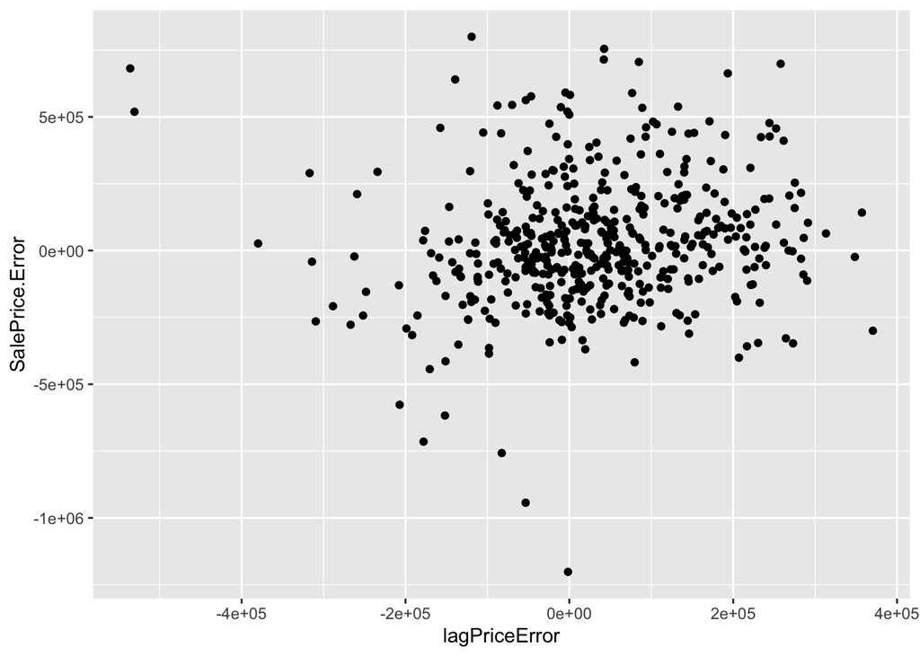

```r
coords.test <-  st_coordinates(boston.test)

neighborList.test <- knn2nb(knearneigh(coords.test, 5))

spatialWeights.test <- nb2listw(neighborList.test, style="W")

boston.test %>%
  mutate(lagPriceError = lag.listw(spatialWeights.test, SalePrice.Error)) %>%
  ggplot()+
  geom_point(aes(x =lagPriceError, y =SalePrice.Error))
```

## Do Errors Cluster? Using Moran’s I

So - is your Moran’s I statistic indicating dispersion (-1), randomness (0) or clustering (1)?

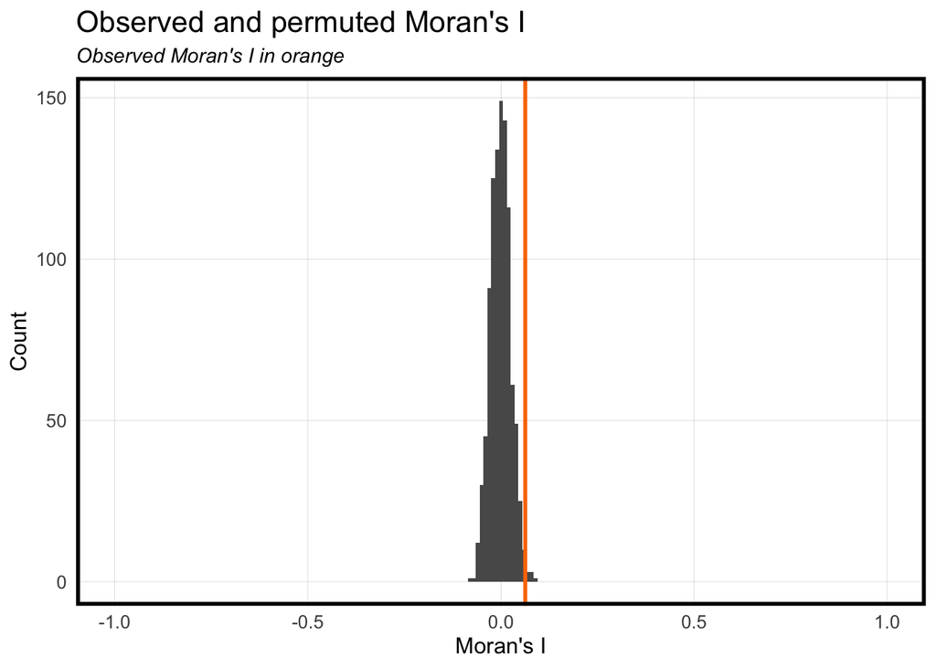

```r
moranTest <- moran.mc(boston.test$SalePrice.Error,
                      spatialWeights.test, nsim = 999)

ggplot(as.data.frame(moranTest$res[c(1:999)]), aes(moranTest$res[c(1:999)])) +
  geom_histogram(binwidth = 0.01) +
  geom_vline(aes(xintercept = moranTest$statistic), colour = "#FA7800",size=1) +
  scale_x_continuous(limits = c(-1, 1)) +
  labs(title="Observed and permuted Moran's I",
       subtitle= "Observed Moran's I in orange",
       x="Moran's I",
       y="Count") +
  plotTheme()
```

## Predictions by neighborhood

```r
boston.test %>%
as.data.frame() %>%
  group_by(Name) %>%
    summarize(meanPrediction = mean(SalePrice.Predict),
              meanPrice = mean(SalePrice)) %>%
      kable() %>%
  kable_styling()
```

| Name | meanPrediction | meanPrice |
| --- | --- | --- |
| Beacon Hill | 3046980.8 | 2774250.0 |
| Charlestown | 1113487.6 | 977124.5 |
| Dorchester | 552973.5 | 533223.7 |
| East Boston | 608076.2 | 504214.8 |
| Hyde Park | 512781.1 | 396038.1 |
| Jamaica Plain | 758669.6 | 862901.3 |
| Mattapan | 513921.9 | 429284.2 |
| Mission Hill | 593450.2 | 1259500.0 |
| Roslindale | 499541.1 | 486234.7 |
| Roxbury | 568628.8 | 523814.3 |
| South Boston | 636543.0 | 720319.2 |
| South End | 2865893.6 | 3304750.0 |
| West Roxbury | 555951.6 | 516277.3 |

## Regression with neighborhood effects

Let’s try to run the regression again, but this time with a neighborhood fixed effect

```r
reg.nhood <- lm(SalePrice ~ ., data = as.data.frame(boston.training) %>%
                                 dplyr::select(Name, SalePrice, LivingArea,
                                               Style, GROSS_AREA, NUM_FLOORS.cat,
                                               R_BDRMS, R_FULL_BTH, R_HALF_BTH,
                                               R_KITCH, R_AC, R_FPLACE,crimes.Buffer))

boston.test.nhood <-
  boston.test %>%
  mutate(Regression = "Neighborhood Effects",
         SalePrice.Predict = predict(reg.nhood, boston.test),
         SalePrice.Error = SalePrice.Predict- SalePrice,
         SalePrice.AbsError = abs(SalePrice.Predict- SalePrice),
         SalePrice.APE = (abs(SalePrice.Predict- SalePrice)) / SalePrice)%>%
  filter(SalePrice < 5000000)
```

How do these models compare? We can bind our error info together and then examine!

```r
bothRegressions <-
  rbind(
    dplyr::select(boston.test, starts_with("SalePrice"), Regression, Name) %>%
      mutate(lagPriceError = lag.listw(spatialWeights.test, SalePrice.Error)),
    dplyr::select(boston.test.nhood, starts_with("SalePrice"), Regression, Name) %>%
      mutate(lagPriceError = lag.listw(spatialWeights.test, SalePrice.Error)))
```

Why do these values differ from those in the book?

```r
st_drop_geometry(bothRegressions) %>%
  gather(Variable, Value, -Regression, -Name) %>%
  filter(Variable == "SalePrice.AbsError" | Variable == "SalePrice.APE") %>%
  group_by(Regression, Variable) %>%
    summarize(meanValue = mean(Value, na.rm = T)) %>%
    spread(Variable, meanValue) %>%
    kable()
```

| Regression | SalePrice.AbsError | SalePrice.APE |
| --- | --- | --- |
| Baseline Regression | 173921.52 | 0.2157040 |
| Neighborhood Effects | 98553.36 | 0.1752957 |

## Further examination of errors

Predicted versus observed plots - what does it mean if the line is above or below y=x?

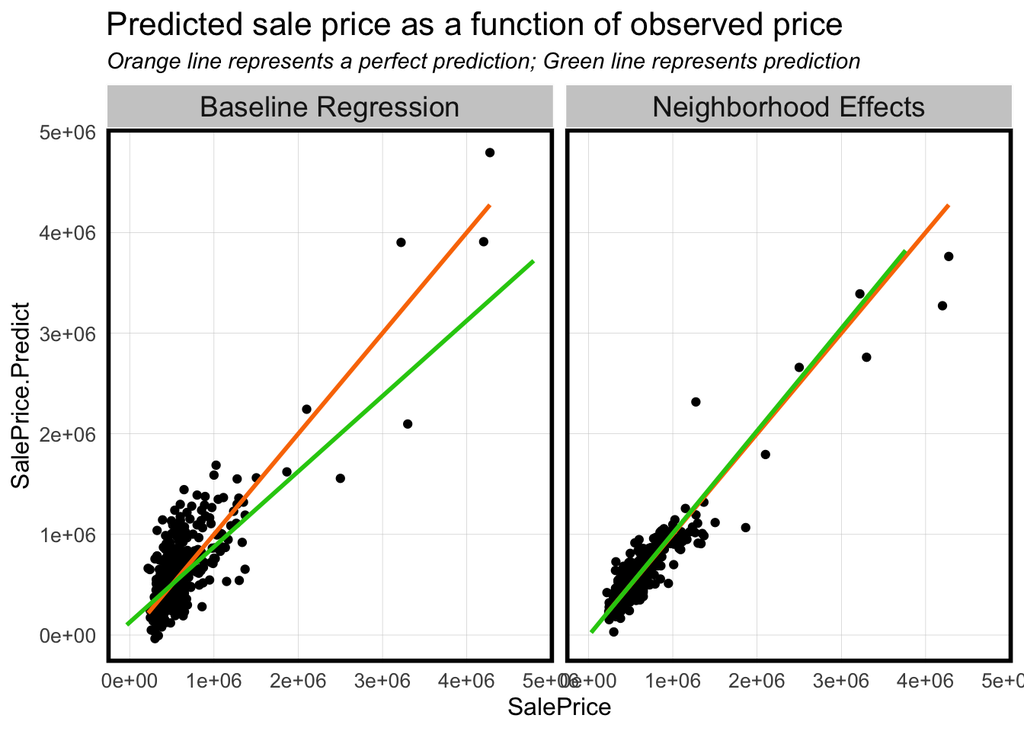

```r
bothRegressions %>%
  dplyr::select(SalePrice.Predict, SalePrice, Regression) %>%
    ggplot(aes(SalePrice, SalePrice.Predict)) +
  geom_point() +
  stat_smooth(aes(SalePrice, SalePrice),
             method = "lm", se = FALSE, size = 1, colour="#FA7800") +
  stat_smooth(aes(SalePrice.Predict, SalePrice),
              method = "lm", se = FALSE, size = 1, colour="#25CB10") +
  facet_wrap(~Regression) +
  labs(title="Predicted sale price as a function of observed price",
       subtitle="Orange line represents a perfect prediction; Green line represents prediction") +
  plotTheme()
```

We can also examine the spatial pattern of errors.

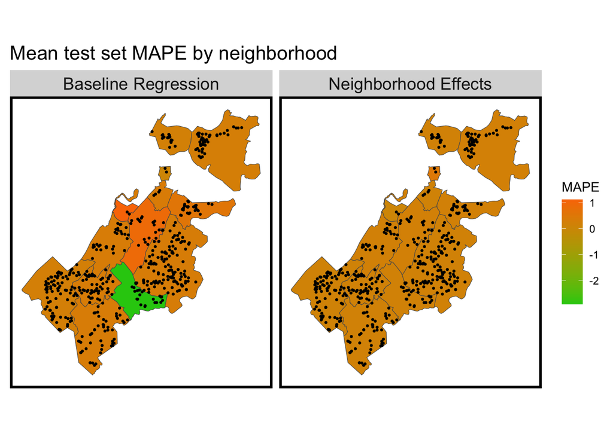

```r
st_drop_geometry(bothRegressions) %>%
  group_by(Regression, Name) %>%
  summarize(mean.MAPE = mean(SalePrice.APE, na.rm = T)) %>%
  ungroup() %>%
  left_join(nhoods, by = c("Name" = "neighborhood")) %>%
    st_sf() %>%
    ggplot() +
      geom_sf(aes(fill = mean.MAPE)) +
      geom_sf(data = bothRegressions, colour = "black", size = .5) +
      facet_wrap(~Regression) +
      scale_fill_gradient(low = palette5[1], high = palette5[5],
                          name = "MAPE") +
      labs(title = "Mean test set MAPE by neighborhood") +
      mapTheme()
```

## Race and income context of predictions

What is the race and income context of Boston census tracts, and how does this relate to our model performance?

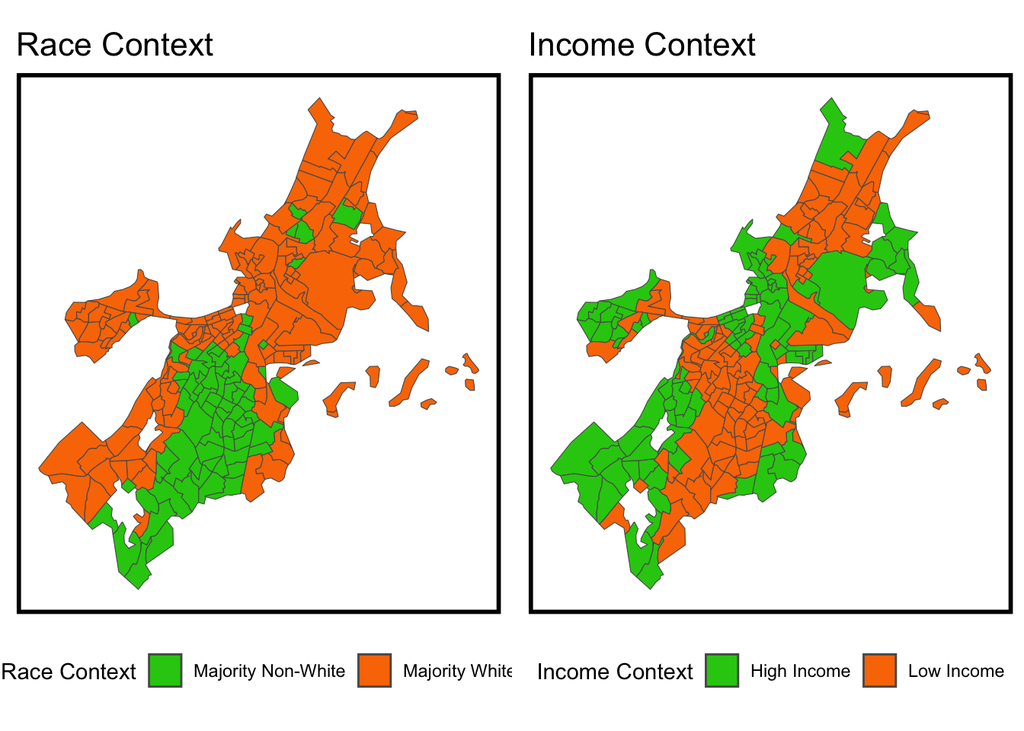

```r
tracts17 <-
  get_acs(geography = "tract", variables = c("B01001_001E","B01001A_001E","B06011_001"),
          year = 2017, state=25, county=025, geometry=T, output = "wide") %>%
  st_transform('ESRI:102286')  %>%
  rename(TotalPop = B01001_001E,
         NumberWhites = B01001A_001E,
         Median_Income = B06011_001E) %>%
  mutate(percentWhite = NumberWhites / TotalPop,
         raceContext = ifelse(percentWhite > .5, "Majority White", "Majority Non-White"),
         incomeContext = ifelse(Median_Income > 32322, "High Income", "Low Income"))
grid.arrange(ncol = 2,
  ggplot() + geom_sf(data = na.omit(tracts17), aes(fill = raceContext)) +
    scale_fill_manual(values = c("#25CB10", "#FA7800"), name="Race Context") +
    labs(title = "Race Context") +
    mapTheme() + theme(legend.position="bottom"),
  ggplot() + geom_sf(data = na.omit(tracts17), aes(fill = incomeContext)) +
    scale_fill_manual(values = c("#25CB10", "#FA7800"), name="Income Context") +
    labs(title = "Income Context") +
    mapTheme() + theme(legend.position="bottom"))
```

```r
st_join(bothRegressions, tracts17) %>%
  filter(!is.na(incomeContext)) %>%
  group_by(Regression, incomeContext) %>%
  summarize(mean.MAPE = scales::percent(mean(SalePrice.APE, na.rm = T))) %>%
  st_drop_geometry() %>%
  spread(incomeContext, mean.MAPE) %>%
  kable(caption = "Test set MAPE by neighborhood income context")
```

Test set MAPE by neighborhood income context

| Regression | High Income | Low Income |
| --- | --- | --- |
| Baseline Regression | 28% | 13% |
| Neighborhood Effects | 15% | 20% |